# Free Recall Example

Nicholas Maxwell, Erin Buchanan

2021-11-28

# Libraries and Data

Please see manuscript for a long description of the following data. We will load the example data, and you can use the `?` with the dataset name to learn more about the data.

```r
library(lrd)
data("wide_data")
head(wide_data)
```

```
#>   Sub.ID
#> 1      1
#> 2      2
#> 3      3
#> 4      4
#> 5      5
#> 6      6
#>                                                                                                Response
#> 1            basket, chair, clothes, flowrs, glasses, fan, windows, carpet, lamp, picture frame, remote
#> 2                                                                  windows, bed, books, shelf, pictures
#> 3 bacpack, chair, glasses, mirror, iphone, pillow, stereo, nightstand, computer, door, magazines, quilt
#> 4                                vase, blinds, computer, magazine, books, bed, blanket, carpet, dresser
#> 5                                                            bed, blankets, closet, windows, books, fan
#> 6                                     bed, blankets, dreser, nightstand, end table, stereo, flwrs, vase
#>   Disease.Condition
#> 1           healthy
#> 2           healthy
#> 3           healthy
#> 4              sick
#> 5              sick
#> 6              sick
```

```r
#?wide_data

data("answer_key_free")
head(answer_key_free)
```

```
#>   Answer_Key
#> 1   backpack
#> 2     basket
#> 3        bed
#> 4    blanket
#> 5     blinds
#> 6      books
```

```r
#?answer_key_free

library(ggplot2)
```

# Data Restructuring

```r
DF_long <- arrange_data(data = wide_data,
      responses = "Response",
      sep = ",",
      id = "Sub.ID")
head(DF_long)
```

```
#>   Sub.ID response position Disease.Condition
#> 1      1   basket        1           healthy
#> 2      1    chair        2           healthy
#> 3      1  clothes        3           healthy
#> 4      1   flowrs        4           healthy
#> 5      1  glasses        5           healthy
#> 6      1      fan        6           healthy
```

# Data Cleanup

Scoring in `lrd` is case sensitive, so we will use `tolower()` to lower case all correct answers and participant answers.

```r
DF_long$response <- tolower(DF_long$response)
answer_key_free$Answer_Key <- tolower(answer_key_free$Answer_Key)
```

# Score the Data

You should define the following:

- data = dataframe of participant responses
- responses = column name of the participant answers
- key = column name of the answer key
- id = column name of the participant id number
- cutoff = the Levenshtein distance value you want to use for scoring (0 no changes exactly the same, higher numbers allow more variance in the word)
- flag = calculate z scores for outliers (TRUE/FALSE)
- group.by = column name(s) for grouping variables

```r
free_output <- prop_correct_free(data = DF_long,
                                 responses = "response",
                                 key = answer_key_free$Answer_Key,
                                 id = "Sub.ID",
                                 cutoff = 1,
                                 flag = TRUE,
                                 group.by = "Disease.Condition")


str(free_output)
```

```
#> List of 3
#>  $ DF_Scored     :'data.frame':  51 obs. of  6 variables:
#>   ..$ Responses        : chr [1:51] "bacpack" "basket" "bed" "bed" ...
#>   ..$ Sub.ID           : num [1:51] 3 1 2 4 5 6 4 6 5 4 ...
#>   ..$ position         : num [1:51] 1 1 2 6 1 1 7 2 2 2 ...
#>   ..$ Disease.Condition: chr [1:51] "healthy" "healthy" "healthy" "sick" ...
#>   ..$ Answer           : chr [1:51] "backpack" "basket" "bed" "bed" ...
#>   ..$ Scored           : num [1:51] 1 1 1 1 1 1 1 1 1 1 ...
#>  $ DF_Participant:'data.frame':  6 obs. of  5 variables:
#>   ..$ Disease.Condition  : chr [1:6] "healthy" "healthy" "healthy" "sick" ...
#>   ..$ Sub.ID             : num [1:6] 1 2 3 4 5 6
#>   ..$ Proportion.Correct : num [1:6] 0.393 0.143 0.393 0.321 0.214 ...
#>   ..$ Z.Score.Group      : num [1:6] 0.577 -1.155 0.577 1.155 -0.577 ...
#>   ..$ Z.Score.Participant: num [1:6, 1] 1.082 -1.31 1.082 0.399 -0.626 ...
#>   .. ..- attr(*, "scaled:center")= num 0.28
#>   .. ..- attr(*, "scaled:scale")= num 0.105
#>  $ DF_Group      :'data.frame':  2 obs. of  4 variables:
#>   ..$ Disease.Condition: chr [1:2] "healthy" "sick"
#>   ..$ Mean             : num [1:2] 0.31 0.25
#>   ..$ SD               : num [1:2] 0.1443 0.0619
#>   ..$ N                : int [1:2] 3 3
```

# Output

We can use `DF_Scored` to see the original dataframe with our new scored column - also to check if our answer key and participant answers matched up correctly! The `DF_Participant` can be used to view a participant level summary of the data. Last, if a grouping variable is used, we can use `DF_Group` to see that output.

```r
#Overall
free_output$DF_Scored
```

```
#>        Responses Sub.ID position Disease.Condition
#> 1        bacpack      3        1           healthy
#> 2         basket      1        1           healthy
#> 3            bed      2        2           healthy
#> 4            bed      4        6              sick
#> 5            bed      5        1              sick
#> 6            bed      6        1              sick
#> 7        blanket      4        7              sick
#> 8       blankets      6        2              sick
#> 9       blankets      5        2              sick
#> 10        blinds      4        2              sick
#> 11         books      5        5              sick
#> 12         books      2        3           healthy
#> 13         books      4        5              sick
#> 14        carpet      1        8           healthy
```

[output cut: 89 more lines]

```r
#Participant
free_output$DF_Participant
```

```
#>   Disease.Condition Sub.ID Proportion.Correct
#> 1           healthy      1          0.3928571
#> 2           healthy      2          0.1428571
#> 3           healthy      3          0.3928571
#> 4              sick      4          0.3214286
#> 5              sick      5          0.2142857
#> 6              sick      6          0.2142857
#>   Z.Score.Group Z.Score.Participant
#> 1     0.5773503           1.0819232
#> 2    -1.1547005          -1.3096965
#> 3     0.5773503           1.0819232
#> 4     1.1547005           0.3986033
#> 5    -0.5773503          -0.6263766
#> 6    -0.5773503          -0.6263766
```

```r
#Group
free_output$DF_Group
```

```
#>   Disease.Condition      Mean         SD N
#> 1           healthy 0.3095238 0.14433757 3
#> 2              sick 0.2500000 0.06185896 3
```

# Other Possible Calculations

## Serial Position

This function prepares the data for a serial position curve analysis or visualization. Please note, it assumes you are using the output from above, but any output with these columns would work fine. The arguments are roughly the same as the overall scoring function. We’ve also included some `ggplot2` code as an example to help show how you might use our output for plotting. These graphs aren’t too exciting with a small example!

```r
serial_output <- serial_position(data = free_output$DF_Scored,
                                 key = answer_key_free$Answer_Key,
                                 position = "position",
                                 scored = "Scored",
                                 answer = "Answer",
                                 group.by = "Disease.Condition")

head(serial_output)
```

```
#>   Disease.Condition Tested.Position Freq
#> 1           healthy               1    1
#> 2           healthy               2    1
#> 3           healthy               3    1
#> 4              sick               3    0
#> 5              sick               4    0
#> 6              sick               5    0
#>   Proportion.Correct        SE
#> 1          0.3333333 0.2721655
#> 2          0.3333333 0.2721655
#> 3          0.3333333 0.2721655
#> 4          0.0000000 0.0000000
#> 5          0.0000000 0.0000000
#> 6          0.0000000 0.0000000
```

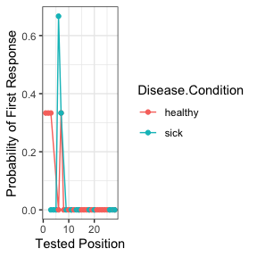

```r
ggplot(serial_output, aes(Tested.Position, Proportion.Correct, color = Disease.Condition)) +
  geom_line() +
  geom_point() +
  xlab("Tested Position") +
  ylab("Probability of First Response") +
  theme_bw()
```

## Conditional Response Probability

Conditional response probability is the likelihood of answers given the current answer set. Therefore, the column participant_lags represents the lag between the written and tested position (e.g., *chair* was listed second, which represents a lag of -6 from spot number 8 on the answer key list). The column `Freq` represents the frequency of the lags between listed and shown position, while the `Possible.Freq` column indicates the number of times that frequency could occur given each answer listed (e.g., given the current answer, a tally of the possible lags that could still occur). The `CRP` column calculates the conditional response probability, or the frequency column divided by the possible frequencies of lags.

```r
crp_output <- crp(data = free_output$DF_Scored,
                  key = answer_key_free$Answer_Key,
                  position = "position",
                  scored = "Scored",
                  answer = "Answer",
                  id = "Sub.ID")

head(crp_output)
```

```
#>   Sub.ID participant_lags Freq Possible.Freq
#> 1      1              -27    0             0
#> 2      1              -26    0             0
#> 3      1              -25    0             0
#> 4      1              -24    0             0
#> 5      1              -23    0             0
#> 6      1              -22    0             0
#>   Disease.Condition CRP
#> 1           healthy   0
#> 2           healthy   0
#> 3           healthy   0
#> 4           healthy   0
#> 5           healthy   0
#> 6           healthy   0
```

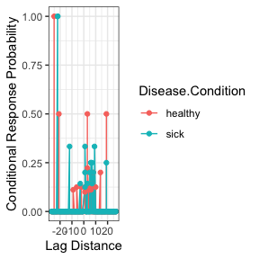

```r
crp_output$participant_lags <- as.numeric(as.character(crp_output$participant_lags))

ggplot(crp_output, aes(participant_lags, CRP, color = Disease.Condition)) +
  geom_line() +
  geom_point() +
  xlab("Lag Distance") +
  ylab("Conditional Response Probability") +
  theme_bw()
```

## Probability of First Response

Participant answers are first filtered for their first response, and these are matched to the original order on the answer key list (`Tested.Position`). Then the frequency (`Freq`) of each of those answers is tallied and divided by the number of participants overall or by group if the `group.by` argument is included (`pfr`).

```r
pfr_output <- pfr(data = free_output$DF_Scored,
                  key = answer_key_free$Answer_Key,
                  position = "position",
                  scored = "Scored",
                  answer = "Answer",
                  id = "Sub.ID",
                  group.by = "Disease.Condition")

head(pfr_output)
```

```
#>   Tested.Position Disease.Condition Freq       pfr
#> 1               1           healthy    1 0.3333333
#> 2               2           healthy    1 0.3333333
#> 3               3           healthy    0 0.0000000
#> 4              27           healthy    0 0.0000000
#> 5              28           healthy    1 0.3333333
#> 6               1              sick    0 0.0000000
```

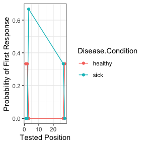

```r
pfr_output$Tested.Position <- as.numeric(as.character(pfr_output$Tested.Position))

ggplot(pfr_output, aes(Tested.Position, pfr, color = Disease.Condition)) +
  geom_line() +
  geom_point() +
  xlab("Tested Position") +
  ylab("Probability of First Response") +
  theme_bw()
```